# Regressie O & S: Bijeenkomst 2

Elmar Jansen

21 mei 2024

# Oefening 1: controleren voor schijnverbanden

## Data laden

Voor deze oefening maken we gebruik van de European Social Survey (ESS) data. We gebruiken ronde 7 uit 2014. Het codebook (met beschrijving van variabelen) vind je hier.

### R

```r
library(haven)
ess7 <- read_sav("https://elmarjansen.nl/data/ESS7e02_3.sav")
```

### SPSS

1. Download het bestand [hier](https://elmarjansen.nl/data/ESS7e02_3.sav).
2. Open het bestand in SPSS.

## Opdracht

We voeren een regressie uit om het effect te onderzoeken van lichaamsgewicht op (politieke) links / rechts-positie.

We beginnen met een regressie om het effect van `weight` op `lrscale` te onderzoeken. Beantwoord de volgende vragen voordat je de de regressie uitvoert:

## Variabelen

### Vraag

Bedenk voordat we verdergaan wat hier de *afhankelijke variabele* is en wat de *onafhankelijke variabele* is. Zou het ook andersom kunnen?

### Antwoord

- De **afhankelijke variabele** is links-rechts-positie (`lrscale`).
- De **onafhankelijke variabele** is gewicht (`weight`).

## Regressievergelijking

### Vraag

Schrijf nu voor jezelf eerst de regressievergelijking uit. Dit is de vergelijking die we straks gaan invullen.

### Antwoord

De regressievergelijking is:

$${lrscale}_i = \beta_0 + \beta_1 \times {weight}_i + \epsilon_i$$

## Regressie uitvoeren

Voer nu de regressie uit.

### Instructies

Als je niet meer weet hoe, kies je je software hierboven voor instructies.

### R

```r
model1 <- lm(lrscale ~ weight, data = ess7)
summary(model1)
```

```
##
## Call:
## lm(formula = lrscale ~ weight, data = ess7)
##
## Residuals:
##     Min      1Q  Median      3Q     Max
## -5.4834 -1.1089 -0.0646  1.7992  5.0512
##
## Coefficients:
##              Estimate Std. Error t value Pr(>|t|)
## (Intercept) 4.8194720  0.0586480  82.176  < 2e-16 ***
## weight      0.0034046  0.0007636   4.459 8.26e-06 ***
## ---
## Signif. codes:  0 '***' 0.001 '**' 0.01 '*' 0.05 '.' 0.1 ' ' 1
##
## Residual standard error: 2.23 on 34957 degrees of freedom
##   (5226 observations deleted due to missingness)
## Multiple R-squared:  0.0005684,  Adjusted R-squared:  0.0005399
## F-statistic: 19.88 on 1 and 34957 DF,  p-value: 8.262e-06
```

### SPSS

1. Ga naar `Analyze` > `Regression` > `Linear`.
2. Zet `lrscale` als afhankelijke variabele en `weight` als onafhankelijke variabele.
3. Klik op `Statistics` en zet een vinkje bij `Estimates` en bij `Confidence Intervals`, en druk op Continue.
4. Druk op OK.

## Regressievergelijking ingevuld

### Vraag

Schrijf nu voor jezelf de regressievergelijking uit, maar dan met de geschatte waarden voor $\beta_0$ en $\beta_1$ ingevuld.

### Antwoord

De geschatte regressievergelijking is:

$$\text{lrscale}_i = 4.82 + 0.0034 \times \text{weight}_i + \epsilon_i$$

## Interpretatie constante

### Vraag

Bedenk de precieze interpretatie van het getal 4.82 (de constante $\beta_0$).

### Antwoord

De constante $\beta_0$ is 4.82.

Dit betekent dat als iemand 0 kg weegt, diegene gemiddeld 4.82 links/rechts is.

## Interpretatie helling

### Vraag

Bedenk de precieze interpretatie van het getal 0.0034 (de helling-coefficient $\beta_1$). Kijk ook naar de indicatoren van onzekerheid: standaardfout, betrouwbaarheidsinterval (in SPSS) en p-waarde.

### Antwoord

De helling-coefficient $\beta_1$ is 0.0034.

Dit betekent dat voor iedere kilo dat iemand zwaarder is, diegene 0.0034 punten rechtser wordt.

Dit effect is vrij nauwkeurig gemeten (lage standaardfout - logisch met zo’n grote N). Het is ook significant (p < 0.05): het is niet waarschijnlijk dat het effect eigenlijk precies 0 is.

## Controleren?

### Vraag

Mogelijk (waarschijnlijk!) is hier sprake van een schijnverband. Bedenk een of meerdere variabelen die dit schijnverband zouden kunnen veroorzaken.

### Antwoord

Een schijnverband zou kunnen ontstaan als er een derde variabele is die zowel het gewicht als de links-rechts-positie beïnvloedt. Mogelijke variabelen: - Gender / geslacht (mannen zijn gemiddeld zwaarder en rechtser) - Leeftijd (oudere mensen zijn gemiddeld zwaarder en rechtser) - Opleiding (hoger-opgeleiden zijn gemiddeld lichter en linkser) - Inkomen? - etc.

## Controleren!

### Vraag

Voer een regressie uit waarin je controleert voor gender (`gndr`). - Geef de regressievergelijking (ingevuld) - Wat is er gebeurd met het effect van gewicht op links-rechts-positie? - Kun je dit verklaren?

### In R

```r
model2 <- lm(lrscale ~ weight + gndr, data = ess7)
summary(model2)
```

```
##
## Call:
## lm(formula = lrscale ~ weight + gndr, data = ess7)
##
## Residuals:
##     Min      1Q  Median      3Q     Max
## -5.2797 -1.1669  0.0004  1.8037  5.0416
##
## Coefficients:
##               Estimate Std. Error t value Pr(>|t|)
## (Intercept)  5.2556703  0.0908527  57.848  < 2e-16 ***
## weight       0.0009813  0.0008548   1.148    0.251
## gndr        -0.1672766  0.0267147  -6.262 3.86e-10 ***
## ---
## Signif. codes:  0 '***' 0.001 '**' 0.01 '*' 0.05 '.' 0.1 ' ' 1
##
## Residual standard error: 2.229 on 34944 degrees of freedom
##   (5238 observations deleted due to missingness)
## Multiple R-squared:  0.001684,   Adjusted R-squared:  0.001627
## F-statistic: 29.47 on 2 and 34944 DF,  p-value: 1.622e-13
```

### In SPSS

1. Ga naar `Analyze` > `Regression` > `Linear`.
2. Zet `lrscale` als afhankelijke variabele en `weight` als onafhankelijke variabele (waarschijnlijk staan ze nog ingevuld) en voeg `gndr` toe als onafhankelijke variabele.
3. Druk op OK.

Extra tip: als je in SPSS de controlevariabele invoert in een nieuw “block” (druk op “next”), voert SPSS automatisch beide regressies uit - dus ook die met alleen `weight`.

### Antwoord

De geschatte regressievergelijking is:

$$\text{lrscale}_i = 5.26 + 0.0009 \times \text{weight}_i - 0.17 \times
\text{gndr}_i + \epsilon_i$$

Het effect van gewicht op links-rechts-positie is nu veel kleiner geworden (en ook niet meer significant).

Blijkbaar kan gender een groot deel van het verband tussen gewicht en links-rechts-positie verklaren: er was inderdaad sprake van een schijnverband.

# Oefening 2: lineariteit controleren

## Data laden

Voor deze oefening maken we gebruik van de buurten-dataset die we ook vorige week gebruikten.

### R

```r
library(haven)
buurten <- read_sav("https://elmarjansen.nl/data/cbs_buurten_amsterdam.sav")
```

### SPSS

Instructies voor SPSS:

1. Download het bestand [hier](https://elmarjansen.nl/data/cbs_buurten_amsterdam.sav).
2. Open het bestand in SPSS.

## Opdracht: regressie

We willen onderzoeken wat het effect is van WOZ-waarde (`woz`) op het percentage corporatiewoningen in een buurt (`woning_huur_corporatie`).

Voer de analyse uit, en rapporteer de resultaten. Onderzoek vervolgens of er mogelijk sprake is van een niet-lineair verband.

### Instructies

Als je niet meer weet hoe, kies je je software hierboven voor instructies.

### In R

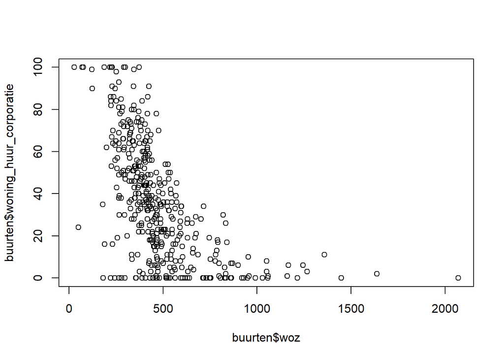

```r
# Regressie
m1 <- lm(woning_huur_corporatie ~ woz, data = buurten)
summary(m1)

# Scatterplot
plot(buurten$woz, buurten$woning_huur_corporatie)
```

[output not shown]

### In SPSS

Regressie:

1. Ga naar `Analyze` > `Regression` > `Linear`.
2. Zet `woning_huur_corporatie` als afhankelijke variabele en `woz` als onafhankelijke variabele.
3. Klik op OK.

Scatterplot:

1. Ga naar `Graphs` > `Legacy Dialogs` > `Scatter/Dot`.
2. Zet `woz` op de x-as en `woning_huur_corporatie` op de y-as.
3. Druk op OK.

### Antwoord

We vinden een sterk negatief effect van WOZ-waarde op het percentage corporatiewoningen in een buurt.

Voor iedere extra 1000 euro WOZ-waarde, daalt het percentage corporatiewoningen met 0.07 procentpunt.

Het verband lijkt in grote lijnen lineair, maar er is wel sprake van een afvlakking: het effect van WOZ-waarde op percentage corporatiewoningen lijkt minder sterk te worden naarmate de WOZ-waarde hoger wordt.

We kunnen het verband dan waarschijnlijk beter modelleren door het logaritme van WOZ-waarde te gebruiken.

## Opdracht: met transformatie

Voer nu de analyse uit, maar met het logaritme van WOZ-waarde, en rapporteer de resultaten. Bekijk ook het nieuwe scatterplot.

### Instructies

Als je niet meer weet hoe, kies je je software hierboven voor instructies.

### In R

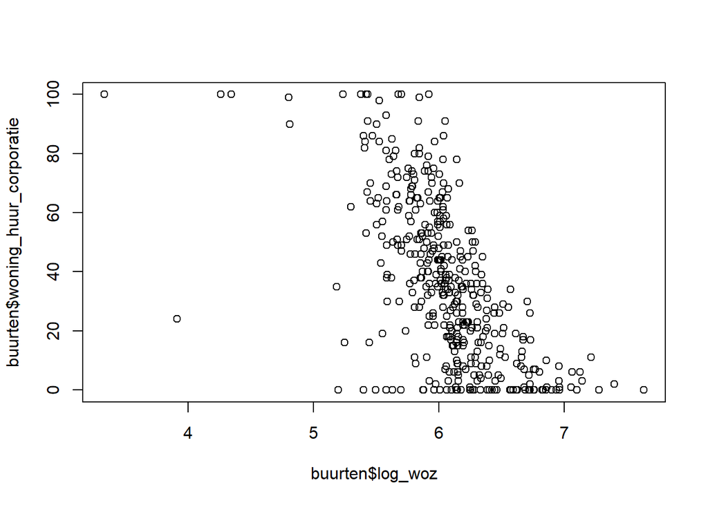

```r
# Transformatie
buurten$log_woz <- log(buurten$woz)

# Regressie
m2 <- lm(woning_huur_corporatie ~ log_woz, data = buurten)

# Scatterplot
plot(buurten$log_woz, buurten$woning_huur_corporatie)
```

```r
summary(m2)
```

[output not shown]

### In SPSS

1. Maak een nieuwe variabele `log_woz` met de logaritme van `woz`:
   1. Transform -> Compute Variable
   2. Zet bij `Target Variable` de naam van de nieuwe variabele (`log_woz`)
   3. Zet bij `Numeric Expression` `Ln(woz)`
   4. Druk op OK
2. Voer een nieuwe regressie uit met `woning_huur_corporatie` als afhankelijke variabele en `log_woz` als onafhankelijke variabele.
3. Maak een scatterplot met `log_woz` op de x-as en `woning_huur_corporatie` op de y-as.

# Oefening 3: extreme waarden

Onderzoek in hoeverre de analyse die we net hebben uitgevoerd (effect van WOZ-waarde op percentage corporatiewoningen) wordt beïnvloed door extreme waarden. Welke buurten zijn dit? Wat gebeurt er als we deze buurten verwijderen?

# Oefening 4: regressieassumpties

Tot slot gaan we alles wat we geleerd hebben toepassen op een nieuwe dataset.

We gebruiken een (helaas gesimuleerde) dataset met gegevens over het succes van bioscoopfilms.

De data geïnstpireerd door de (echte) data die te vinden is op https://filmonderzoek.nl/

## Data laden

### R

```r
library(haven)
films <- read_sav("https://elmarjansen.nl/data/films.sav")
```

### SPSS

1. Download het bestand [hier](https://elmarjansen.nl/data/films.sav).
2. Open het bestand in SPSS.

## Opdracht

We hebben de opdracht gekregen te onderzoeken wat het effect is van bezoekersaantallen op de naamsbekendheid van een film. In de dataset vind je de volgende variabelen:

- `naamsbekendheid`: de gemiddelde naamsbekendheid van de film (0-10), gemeten middels een enquête
- `bezoekers`: het totaal aantal bezoekers van de film in 2023 in Nederlandse bioscopen
- `omzet`: de totale omzet van de film in 2023 in Nederlandse bioscopen in euro’s

We gebruiken eerst een lineaire regressie om het effect te onderzoeken van `bezoekers` op `naamsbekendheid`. Vervolgens voegen we `omzet` toe als controlevariabele.

Voer de analyse uit, en rapporteer de resultaten.

Ga vervolgens na wat hier allemaal (potentieel) mis gaat. Probeer eventueel ook een oplossing te bedenken en uit te voeren.